# R Reference Guide

Melissa Langley

12/16/2021

# R Reference Guide

## Loading Data and Packages

Load the necessary packages

```r
##Load the here( ) package
require(here)
##Load the correct package. In this example, we will load palmerpenguins using require( ) and library( )
require(palmerpenguins)
library(palmerpenguins)
```

```r
gingko <- read.csv(here("data", "ginkgo_data_2021.csv"))
```

## Data Structures

The function c() combines or concatenates its arguments into a vector (a 1-dimensional data structure consisting of 1 or more elements).  
All of the elements must be of the same type.  
I can’t combine character and numeric types in the same call to c()  
Here’s two examples using numeric and character data types:

```r
## Create a vector of numbers:
num_vec  = c(1, 4, 8, 9, 13)

## Create a vector of characters:
char_vec = c("a", "fish", "data is cool")
```

I can show the contents of a vector by typing the name of the vector, or using the print() function.

```r
## Typing the name of the vector into the console prints the contents
num_vec
```

```
## [1]  1  4  8  9 13
```

```r
## The print() function accomplishes the same task:
print(char_vec)
```

```
## [1] "a"            "fish"         "data is cool"
```

See how long the vector or other object is or set the length of the vector or other object.

```r
##See the length of a vector from 1 to 45.
length(c(1:45))
```

```
## [1] 45
```

The function matrix( ) organizes elements into a specified number of rows and columns.  
The elements must be of the same data type. Date types include numeric, character, and logical, but they are all constructed the same way.

```r
##Start creating a matrix by choosing the elements you want in the first argument. This first element can be constructed with either of the following methods:
c(4, 5, 6)
```

```
## [1] 4 5 6
```

```r
4:6
```

```
## [1] 4 5 6
```

```r
##The argument byrow indicates that the matrix is filled by the rows.
byrow = TRUE
##If we want the matrix to be filled by the columns, set byrow to false.
byrow = FALSE
##Name a matrix using the name you want and the information above. Some variations include:
example_matrix <- matrix(4:6, nrow = 3, byrow = TRUE)
example_matrix <- matrix(c(4, 5, 6), nrow = 3, byrow = FALSE)
```

Data frames allow us to analyze data sets with more than one element type. Variables are set as columns and observations are set as rows.

```r
##Create a data frame as follows where "data" specifies the location and the following element specifies the \exact file name.
ginkgo <- read.csv(here("data", "ginkgo_data_2021.csv"))
##See the beginning (head) and end (tail) of the data frame
head(ginkgo)
```

```
##   site_id seeds_present max_width max_depth notch_depth petiole_length
## 1    7719         FALSE        71        40           0             30
## 2    7719         FALSE        64        38           0             23
## 3    7719         FALSE        55        32           0             20
## 4    7719         FALSE        62        40           0             28
## 5    7719         FALSE        65        40           0             25
## 6    7719         FALSE        70        50           0             55
```

```r
tail(ginkgo)
```

```
##     site_id seeds_present max_width max_depth notch_depth petiole_length
## 751    7202         FALSE        78        52           0             39
## 752    7202         FALSE        75        48           0             38
## 753    7202         FALSE        78        52           0             49
## 754    7202         FALSE        65        49           0             48
## 755    7202         FALSE        74        67           0             46
## 756    7202         FALSE       105        64           0             53
```

```r
##See an overview of your data including the number of observations and variables, data types, and more.
str(ginkgo)
```

```
## 'data.frame':    756 obs. of  6 variables:
##  $ site_id       : int  7719 7719 7719 7719 7719 7719 7719 7719 7719 7719 ...
##  $ seeds_present : logi  FALSE FALSE FALSE FALSE FALSE FALSE ...
##  $ max_width     : num  71 64 55 62 65 70 63 56 51 57 ...
##  $ max_depth     : int  40 38 32 40 40 50 42 35 45 37 ...
##  $ notch_depth   : num  0 0 0 0 0 0 0 0 0 0 ...
##  $ petiole_length: num  30 23 20 28 25 55 27 20 50 23 ...
```

```r
##See how many rows are in the gingko data set or set the number of rows in a matrix.
nrow(gingko)
```

```
## [1] 756
```

```r
##See how many columns are in the gingko data set or set the number of columns in a matrix.
ncol(gingko)
```

```
## [1] 6
```

```r
##The dimensions argument tell us how many rows and columns the ginkgo data set has.
dim(gingko)
```

```
## [1] 756   6
```

## Subsetting

Subsetting allows us to see just a portion of the data. Rows, columns, or individual elements can be selected.

```r
##Select a column from the data set.
gingko$petiole_length
```

```
##   [1]  30.00  23.00  20.00  28.00  25.00  55.00  27.00  20.00  50.00  23.00
##  [11]  28.00  26.00  43.00  45.00  42.00  40.00  42.00  40.00  48.00  37.00
##  [21]  50.00  35.00  47.00  23.00  21.00  25.00  41.00  78.00  88.00  38.00
##  [31]  59.00  85.00  42.00  73.00  56.00  76.00  94.00  57.00  30.00  28.00
##  [41]  80.00  58.00  70.00  64.00  43.00  58.00  49.00  35.00  72.00  88.00
##  [51]  63.00  55.00  56.00  54.00  49.00  28.00  57.00  53.00  51.00  80.00
##  [61]  42.00  49.00  49.00  36.00  33.00  46.00  59.00  41.00  58.00  96.00
##  [71]  58.00  45.00  34.00  35.00  59.00  78.00  78.00  41.00  75.00  41.00
##  [81]  30.00  23.00  20.00  28.00  25.00  55.00  27.00  20.00  50.00  23.00
##  [91]  28.00  26.00  43.00  45.00  42.00  40.00  42.00  40.00  48.00  37.00
## [101]  50.00  35.00  47.00  23.00  21.00  25.00  41.00  57.00  40.00  25.00
## [111]  38.00  48.00  48.00  53.00  52.00  52.00  51.00  65.00  48.00  88.00
## [121]  25.00  33.00  68.00  45.00  55.00  51.00  61.00  30.00  37.00  50.00
## [131]  72.00  31.00  54.00  27.00  32.00  59.00  48.00  54.00  93.00  54.00
## [141]  43.00  42.00  14.00  27.00  70.00  58.00  48.00  60.00  52.00  55.00
```

[output cut: 61 more lines]

```r
##Select the first row of the gingko data
help(subset)
ginkgo[1,]
```

```
##   site_id seeds_present max_width max_depth notch_depth petiole_length
## 1    7719         FALSE        71        40           0             30
```

```r
##Select the element in row 2, column 3
ginkgo[2, 3]
```

```
## [1] 64
```

```r
##Select the third column of the gingko data
ginkgo[,3]
```

```
##   [1]  71.0  64.0  55.0  62.0  65.0  70.0  63.0  56.0  51.0  57.0  59.0  63.0
##  [13]  70.0  50.0  56.0  46.0  54.0  62.0  56.0  55.0  59.0  60.0  63.0  61.0
##  [25]  58.0  55.0  53.0  81.0  94.0  75.0  82.0  86.0  79.0  93.0  88.0  76.0
##  [37]  71.0  91.0  71.0  82.0  65.0  83.0  73.0 102.0  78.0  88.0  81.0  70.0
##  [49]  80.0  96.0  80.0  82.0  86.0  87.0  89.0  69.0  93.0  98.0  81.0  79.0
##  [61]  82.0  85.0  81.0  59.0  53.0  83.0  80.0  77.0  81.0  76.0  82.0  81.0
##  [73]  77.0  68.0  41.0  70.0  68.0  80.0  89.0  90.0  71.0  64.0  55.0  62.0
##  [85]  65.0  70.0  63.0  56.0  51.0  57.0  59.0  63.0  70.0  50.0  56.0  46.0
##  [97]  54.0  62.0  56.0  55.0  59.0  60.0  63.0  61.0  58.0  55.0  53.0  77.0
## [109]  72.0  57.0  75.0  75.0  75.0  67.0  74.0  71.0  72.0  55.0  77.0  97.0
## [121]  73.0  64.0  69.0  92.0  64.0  68.0  53.0  97.0 100.0  90.0  89.0  59.0
## [133]  97.0  76.0  85.0  90.0  87.0  85.0  80.0  86.0  89.0  84.0  88.0  80.0
## [145] 102.0  94.0  95.0 109.0  84.0  68.0  59.0  74.0  70.0  71.0  69.0  74.0
## [157]  70.0  78.0  87.0  69.0  60.0  72.0  59.0  75.0  81.0  82.0  74.0  72.0
## [169]  79.0  84.0  75.0  72.0  88.0  80.0  90.0  58.0  61.0  95.0  72.0  90.0
```

[output cut: 48 more lines]

```r
##Retrieve all data for Adelie penguins from the penguin data set
subset(penguins, species == "Adelie")
```

```
##     species    island bill_length_mm bill_depth_mm flipper_length_mm
## 1    Adelie Torgersen           39.1          18.7               181
## 2    Adelie Torgersen           39.5          17.4               186
## 3    Adelie Torgersen           40.3          18.0               195
## 4    Adelie Torgersen             NA            NA                NA
## 5    Adelie Torgersen           36.7          19.3               193
## 6    Adelie Torgersen           39.3          20.6               190
## 7    Adelie Torgersen           38.9          17.8               181
## 8    Adelie Torgersen           39.2          19.6               195
## 9    Adelie Torgersen           34.1          18.1               193
## 10   Adelie Torgersen           42.0          20.2               190
## 11   Adelie Torgersen           37.8          17.1               186
## 12   Adelie Torgersen           37.8          17.3               180
## 13   Adelie Torgersen           41.1          17.6               182
## 14   Adelie Torgersen           38.6          21.2               191
```

[output cut: 291 more lines]

## Numerical Data Exploration

```r
##summary( ) allows us to see important features of a data set for each column. This can include numerical values like the minimum and mean as well as logical values like true and false.
summary(ginkgo)
```

```
##     site_id      seeds_present     max_width        max_depth
##  Min.   : 1896   Mode :logical   Min.   : 16.00   Min.   : 19.00
##  1st Qu.: 3703   FALSE:636       1st Qu.: 63.00   1st Qu.: 43.00
##  Median : 6066   TRUE :120       Median : 74.00   Median : 51.00
##  Mean   : 6079                   Mean   : 74.34   Mean   : 58.51
##  3rd Qu.: 7206                   3rd Qu.: 85.00   3rd Qu.: 66.00
##  Max.   :12982                   Max.   :130.00   Max.   :145.00
##
##   notch_depth    petiole_length
##  Min.   : 0.00   Min.   :  8.00
##  1st Qu.: 0.00   1st Qu.: 34.00
##  Median : 0.00   Median : 47.00
##  Mean   : 2.99   Mean   : 48.25
##  3rd Qu.: 4.00   3rd Qu.: 60.00
##  Max.   :49.00   Max.   :113.00
##                  NA's   :4
```

```r
##mean( ) provides the mean value of a variable within a data set.
mean(gingko$notch_depth)
```

```
## [1] 2.990079
```

```r
##sd( ) provides the standard deviation of a variable within a data set.
sd(ginkgo$max_width)
```

```
## [1] 16.4203
```

## Graphical Data Exploration

Scatterplots

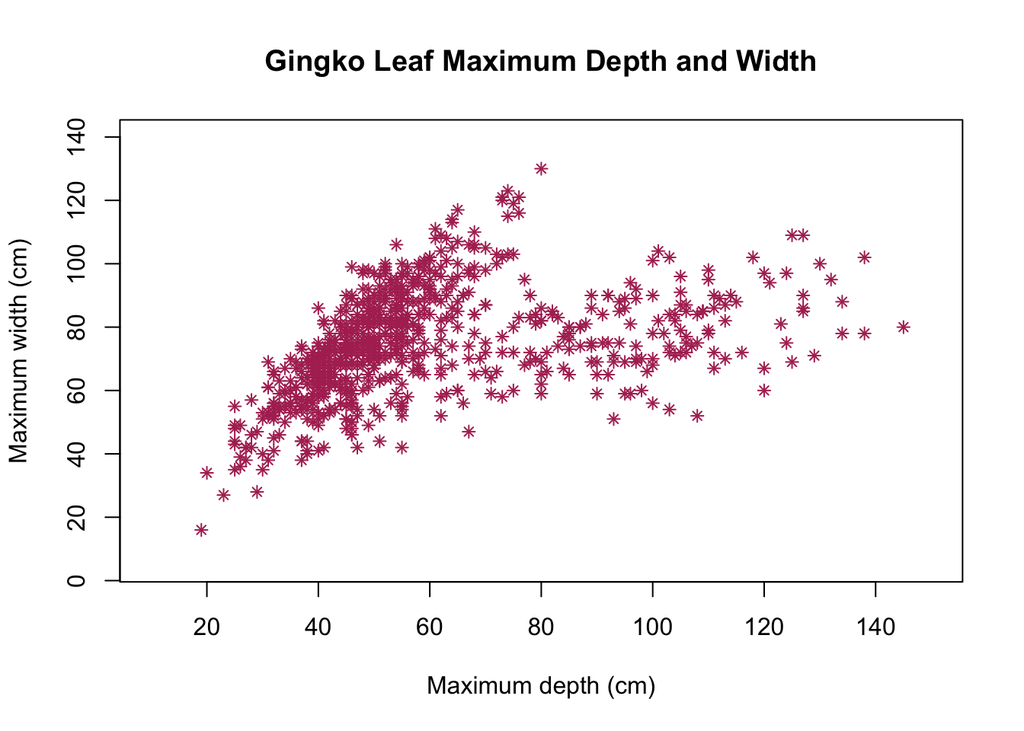

```r
##The plot( ) function makes a scatterplot when you specify the x and y axes.
plot(x = ginkgo$max_depth, y = ginkgo$max_width,
##Specify the title with the argument main and put the title in quotation marks.
     main = "Gingko Leaf Maximum Depth and Width",
##Specify the x and y axis names with xlab and ylab and but the names in quotation marks.
     xlab = "Maximum depth (cm)",
     ylab = "Maximum width (cm)",
##Specify limits for the x and y axes.
     xlim = c(10, 150),
     ylim = c(5, 140),
##Specify the shape of the points in the scatterplot.Choose from a variety of shapes, each of which has a corresponding number.8 is a star.
     pch = 8,
##Specify the size of the points so that they are easier to interpret
     cex = .8,
##Specify the color of the points. Use quotation marks and choose from a wide variety of colors offered by RStudio.
     col = "maroon")
```

Histograms

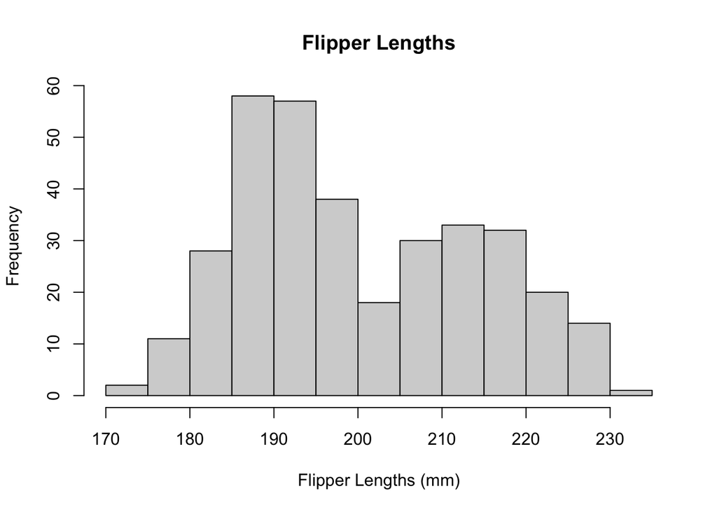

```r
##Histograms are constructed similarly to scatterplots. This one shows flipper lengths from the penguin data set.
hist(penguins$flipper_length_mm, main = "Flipper Lengths", xlab = "Flipper Lengths (mm)",
##The breaks argument specifies the number of columns the data is broken into. This can provide a clearer\ representation of differences within the data set.
     breaks = 15)
```

Boxplots

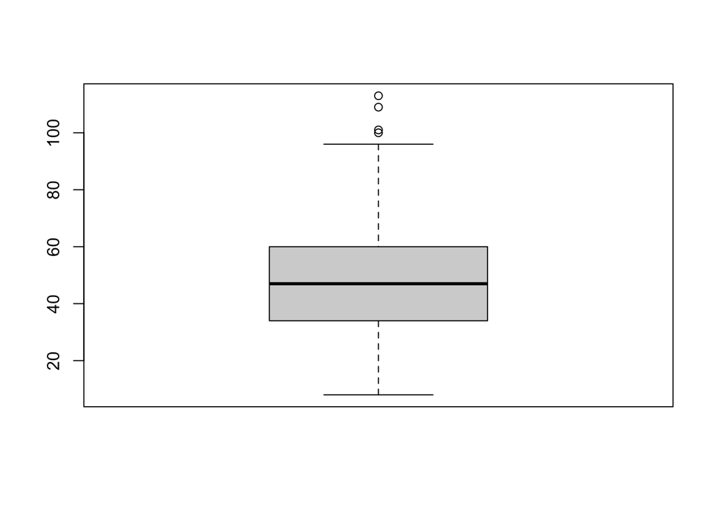

```r
##Boxplots are constructed similarly to scatterplots.This one shows petiole lengths from the gingko data set.
boxplot(gingko$petiole_length)
```

Conditional boxplots

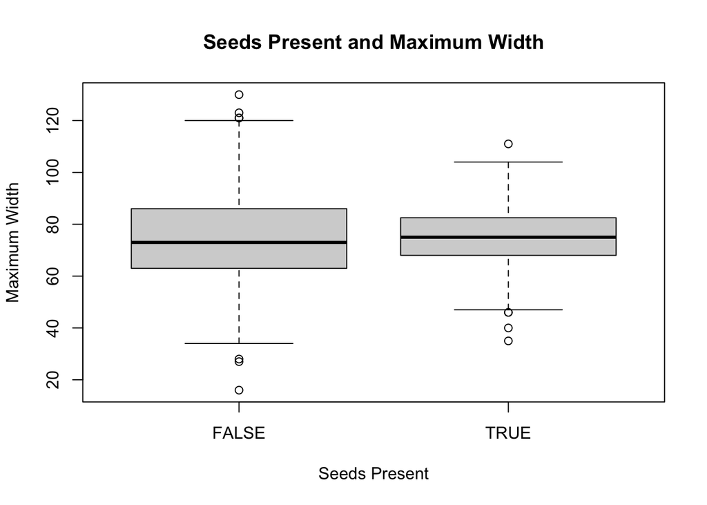

```r
##Conditional boxplots allow for closer analysis of how a variable is conditioned on another variable.
boxplot(max_width ~ seeds_present, data = ginkgo, main = "Seeds Present and Maximum Width", xlab = "Seeds Present", ylab = "Maximum Width")
```

Plots can be combined into different configurations to make panels that are easier to read and to format into other work.

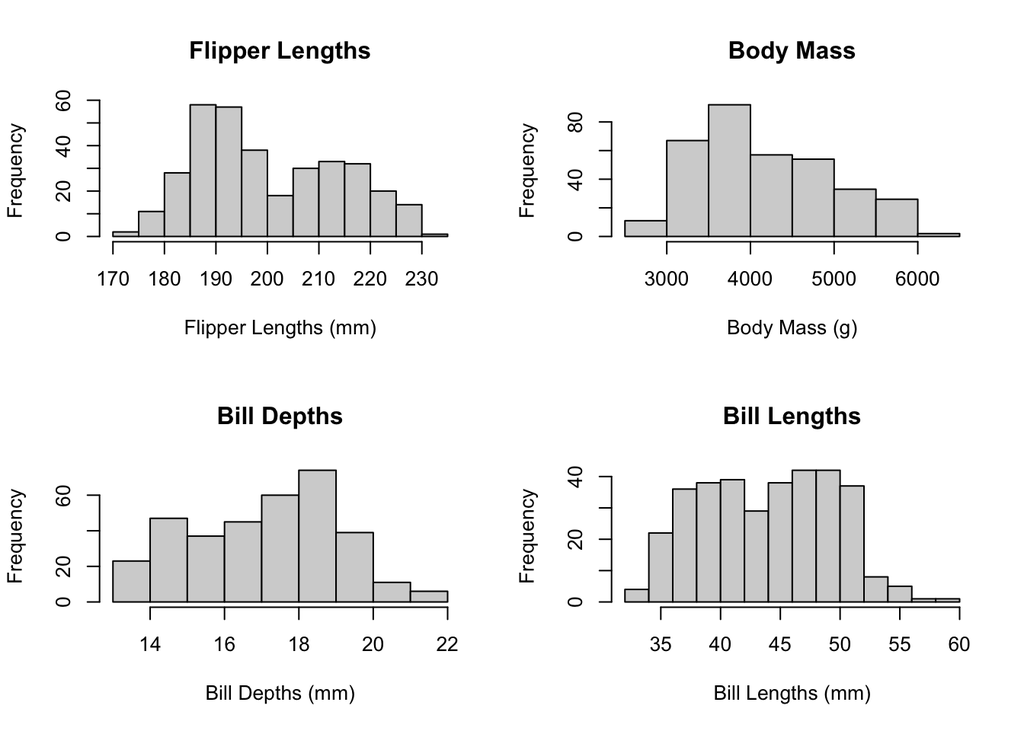

```r
## par(mfrow) organizes the plots into a panel with a specified number of rows and columns.
par(mfrow = c(2, 2))
hist(penguins$flipper_length_mm, main = "Flipper Lengths", xlab = "Flipper Lengths (mm)")
hist(penguins$body_mass_g, main = "Body Mass", xlab = "Body Mass (g)")
hist(penguins$bill_depth_mm, main = "Bill Depths", xlab = "Bill Depths (mm)")
hist(penguins$bill_length_mm, main = "Bill Lengths", xlab = "Bill Lengths (mm)")
```